# Come creare un film di successo

## Perché?

Negli ultimi anni, si è sentito spesso parlare di crisi cinematografica, non solo del cinama italiano, ma anche di quello internazionale.

Solo di recente sono usciti due grandi blockbuster come “**Oppenheimer**” e “**Barbie**”, ma primi di essi bisogna tornare indietro di un paio di anni per trovare un film di notevole successo.

Lo studio che andrò a esporre è dunque mirato a scoprire in che modo si possa creare un film di successo partendo dai dati forniti.

## Le domande

Le domande che mi sono posto per creare un film di successo sono:

- Qual è il genere migliore?
- Chi è il miglior regista?
- Chi è la star migliore?
- Qual è la durata perfetta?

## Dataset

Per questo progetto, è stato utilizzato il seguente dataset scaricato dal sito [Kaggle](https://www.kaggle.com/):

[IMDb 5000 Movie Dataset](https://www.kaggle.com/datasets/carolzhangdc/imdb-5000-movie-dataset).

Le variabili prese in considerazione per questo studio sono state: durata, genere, valutazione di IMDb, regista, star principale, fatturato.

## Genere

Per capire quale sia il genere che crea recensioni più positive, è necessario calcolare la valutazione di IMDb media per ogni genere.

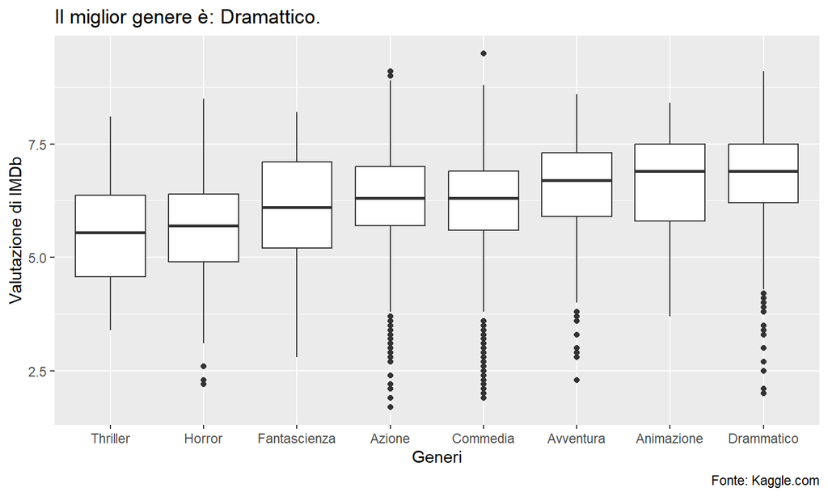

## Regista

È necessario trovare il regista che, in base al suo fatturato, crei la miglior pellicola possibile.

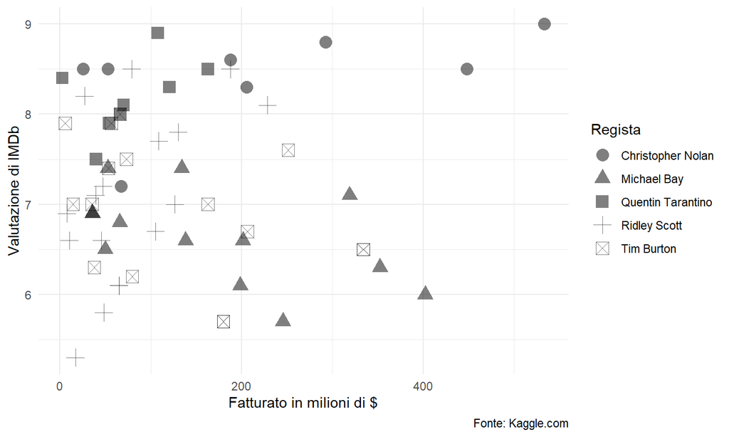

## Regista

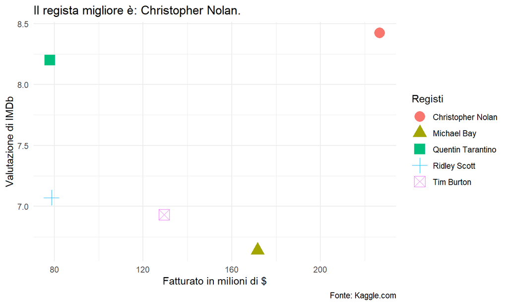

## Star

È fondamentale scegliere il protagonista perfetto tenendo conto della valutazione IMDb dei film in cui ha partecipato e il fatturato che il film ha generato anche grazie alla star principale.

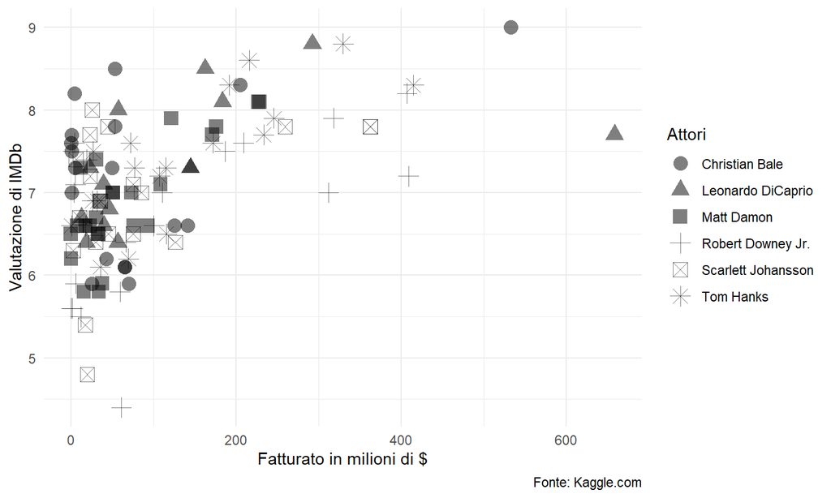

## Star

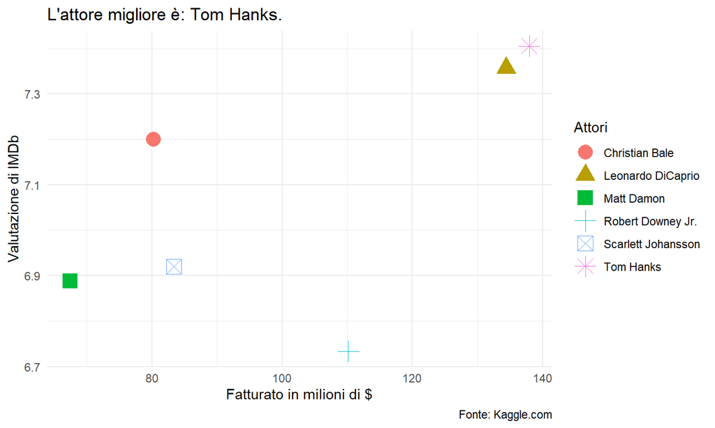

## Durata

Il minutaggio di un film deve essere tale da poter sviluppare una trama avvincente e impressionare la critica.

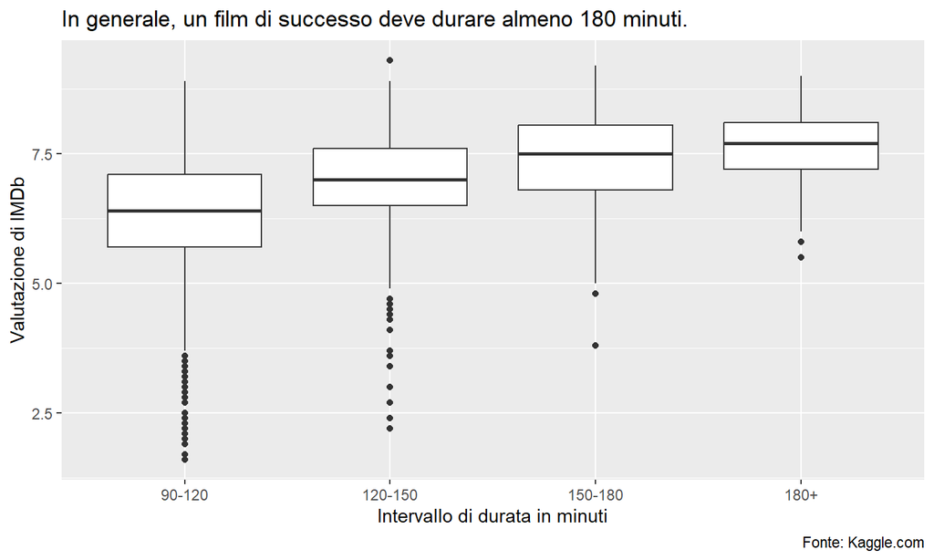

## Conclusioni

Ricapitolando, per creare un film di successo è necessario:

1. scegliere il genere drammatico;
2. farlo girare a Christopher Nolan;
3. ingaggiare Tom Hanks;
4. farlo durare almeno 180 minuti.